# Homework 4

Link to Github repository: https://github.com/grobertson881/stats506-homework4

**Problem 1**

```r
#install.packages("nzelect")
library(nzelect)
library(tidyverse)
nzge <- nzelect::nzge
```

*Part A*

```r
vote_count <- nzge %>%
  select(votes, election_year, voting_type) %>%
  group_by(election_year, voting_type) %>%
  summarize(total_vote_count = sum(votes)) %>%
  arrange(total_vote_count)
vote_count
```

```
# A tibble: 10 × 3
# Groups:   election_year [5]
   election_year voting_type total_vote_count
           <dbl> <chr>                  <dbl>
 1          2002 Candidate            2022115
 2          2002 Party                2040248
 3          2011 Candidate            2225766
 4          2011 Party                2257336
 5          2005 Candidate            2260670
 6          2005 Party                2286190
 7          2008 Candidate            2325598
 8          2008 Party                2356536
 9          2014 Candidate            2375493
10          2014 Party                2416479
```

*Part B*

```r
votes_2014 <- nzge %>%
  filter(election_year == 2014, voting_type == "Candidate") %>%
  group_by(party) %>%
  summarize(party_total_votes = sum(votes)) %>%
  ungroup() %>%
  mutate(vote_proportion = party_total_votes / sum(party_total_votes) * 100) %>%
  select(-party_total_votes) %>%
  arrange(desc(vote_proportion))

votes_2014
```

```
# A tibble: 25 × 2
   party                    vote_proportion
   <chr>                              <dbl>
 1 National Party                    45.5
 2 Labour Party                      33.7
 3 Green Party                        6.98
 4 Conservative Party                 3.41
 5 New Zealand First Party            3.09
 6 Maori Party                        1.77
 7 MANA Movement                      1.36
 8 Informal Candidate Votes           1.17
 9 ACT New Zealand                    1.17
10 United Future                      0.620
# ℹ 15 more rows
```

*Part C*

```r
winning_party <- nzge %>%
  group_by(election_year, voting_type) %>%
  filter(votes == max(votes)) %>%
  select(election_year, voting_type, party)

winning_party
```

```
# A tibble: 10 × 3
# Groups:   election_year, voting_type [10]
   election_year voting_type party
           <dbl> <chr>       <chr>
 1          2002 Party       Labour Party
 2          2002 Candidate   Labour Party
 3          2005 Party       Labour Party
 4          2005 Candidate   Labour Party
 5          2008 Party       National Party
 6          2008 Candidate   National Party
 7          2011 Party       National Party
 8          2011 Candidate   National Party
 9          2014 Party       National Party
10          2014 Candidate   National Party
```

**Problem 2**

```r
tennis <- read_csv("https://raw.githubusercontent.com/JeffSackmann/tennis_atp/refs/heads/master/atp_matches_2019.csv")
```

*Part A*

```r
tourney_2019 <- tennis %>%
  mutate(tourney_date = as.character(tourney_date)) %>%
  filter(str_sub(tourney_date, 1, 4) == "2019") %>%
  summarise(num_tourneys_2019 = n_distinct(tourney_id))

tourney_2019
```

```
# A tibble: 1 × 1
  num_tourneys_2019
              <int>
1               125
```

There were 125 tournaments in 2019.

*Part B*

```r
# winner of tourney is winner of final round
player_wins <- tennis %>%
  filter(round == "F") %>%
  group_by(winner_name) %>%
  summarize(win_count = n()) %>%
  arrange(desc(win_count))

player_wins
```

```
# A tibble: 41 × 2
   winner_name        win_count
   <chr>                  <int>
 1 Dominic Thiem              5
 2 Novak Djokovic             5
 3 Daniil Medvedev            4
 4 Rafael Nadal               4
 5 Roger Federer              4
 6 Alex De Minaur             3
 7 Stefanos Tsitsipas         3
 8 Benoit Paire               2
 9 Cristian Garin             2
10 Jo-Wilfried Tsonga         2
# ℹ 31 more rows
```

Yes, there are 12 players who have won more than one tournament. Dominic Thiem and Novak Djokovic have won the most tournaments with 5 wins.

*Part C*

```r
ace_data <- tennis %>%
  select(w_ace, l_ace) %>%
  pivot_longer(cols = c(w_ace, l_ace),
               names_to = "result", values_to = "aces") %>%
  mutate(result = if_else(result == "w_ace", "W", "L"))

library(infer)

win_ace_hypothesis <- ace_data %>%
  t_test(aces ~ result, alternative = "greater")
win_ace_hypothesis
```

```
# A tibble: 1 × 7
  statistic  t_df p_value alternative estimate lower_ci upper_ci
      <dbl> <dbl>   <dbl> <chr>          <dbl>    <dbl>    <dbl>
1     -10.7 5357.       1 greater        -1.70    -1.97      Inf
```

There is no evidence that winners have more aces than the losers. The p-value of 1 shows there is no statistical proof.

*Part D*

```r
match_data <- tennis %>%
  select(winner_name, loser_name) %>%
  pivot_longer(cols = c(winner_name, loser_name),
               names_to = "result", values_to = "player_name") %>%
  mutate(win = if_else(result == "winner_name", 1, 0))

winning_rate <- match_data %>%
  group_by(player_name) %>%
  summarize(
    matches_played = n(),
    wins = sum(win),
    winning_rate = wins/matches_played
  ) %>%
  filter(matches_played >= 5) %>%
  arrange(desc(winning_rate))

winning_rate
```

```
# A tibble: 167 × 4
   player_name        matches_played  wins winning_rate
   <chr>                       <int> <dbl>        <dbl>
 1 Rafael Nadal                   69    60        0.870
 2 Novak Djokovic                 69    58        0.841
 3 Roger Federer                  66    55        0.833
 4 Daniil Medvedev                80    59        0.738
 5 Kevin Anderson                 15    11        0.733
 6 Dominic Thiem                  69    50        0.725
 7 Attila Balazs                  10     7        0.7
 8 Stefanos Tsitsipas             80    55        0.688
 9 Alex De Minaur                 62    42        0.677
10 Kei Nishikori                  43    29        0.674
# ℹ 157 more rows
```

The player with the highest winning rate is Rafael Nadal with 86.96% of his games being wins.

**Problem 3**

```r
library(ggplot2)
library(tidyverse)
library(lubridate)
covid <- read_csv("https://raw.githubusercontent.com/nytimes/covid-19-data/refs/heads/master/rolling-averages/us-states.csv")
```

*Part A*

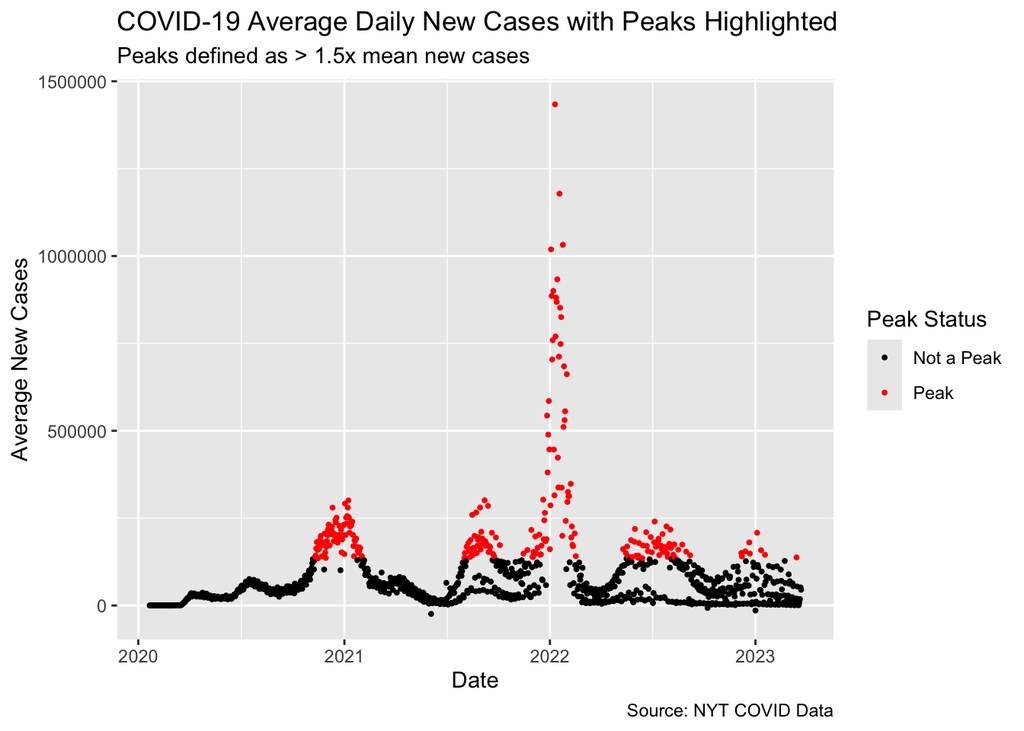

```r
cases_total <- covid %>%
  group_by(date) %>%
  summarize(new_cases = sum(cases, na.rm = TRUE)) %>%
  mutate(peak = ifelse(new_cases > 1.5*mean(new_cases, na.rm = TRUE), 1, 0)) %>%
  arrange(date)

# peaks defined as 1.5x larger than the average

ggplot(cases_total, aes(x = date, y = new_cases, color = factor(peak))) +
  geom_point(size = 0.7) +
  scale_color_manual(
    values = c("0" = "black", "1" = "red"),
    name = "Peak Status",
    labels = c("Not a Peak", "Peak")
  ) +
  labs(
    x = "Date",
    y = "Average New Cases",
    title = "COVID-19 Average Daily New Cases with Peaks Highlighted",
    subtitle = "Peaks defined as > 1.5x mean new cases",
    caption = "Source: NYT COVID Data"
  )
```

There was a major spike in new cases around the start of 2022. There were four minor spikes in the beginning of 2021, around September 2021, around July of 2022, and at the beginning of 2023. As seen in the plot, these spikes are represented in red and are defined as being greater than 1.5x the average number of new cases for all the data.

*Part B*

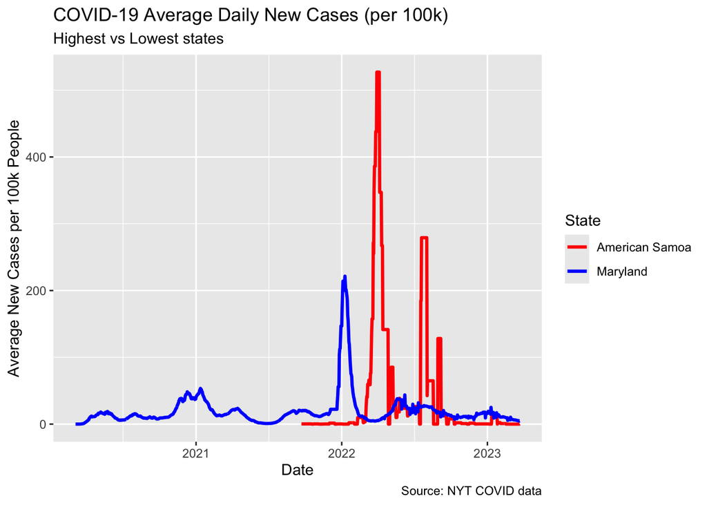

```r
data_by_state <- covid %>%
  group_by(state) %>%
  summarize(avg_new_case_rate = mean(cases_avg_per_100k, na.rm = TRUE)) %>%
  arrange(desc(avg_new_case_rate))

highest_state <- data_by_state$state[1]
lowest_state  <- data_by_state$state[nrow(data_by_state)]

high_low_state_data <- covid %>%
  filter(state == highest_state | state == lowest_state)

ggplot(high_low_state_data, aes(x = date, y = cases_avg_per_100k, color = state)) +
  geom_line(size = 1.1) +
  scale_color_manual(name = "State", values = setNames(c("red", "blue"),
                                                       c(highest_state, lowest_state))) +
  labs(
    x = "Date",
    y = "Average New Cases per 100k People",
    title = "COVID-19 Average Daily New Cases (per 100k)",
    subtitle = "Highest vs Lowest states",
    caption = "Source: NYT COVID data"
  )
```

The state with the highest average rates per 100k is American Somoa and the lowest averages rates per 100k is Maryland. In the graph, American Samoa is represented in red and Maryland is represented in blue. The dates that American Samoa tracked their COVID-19 cases starts much later than Maryland so the trends can’t be tracked before 2022. After that though, we can see the trends differ greatly where as the cases are lowering after 2022 for Maryland, there are significant spikes in cases for American Samoa. This may be due to differences in vaccine distribution at this time in the two places.

*Part C*

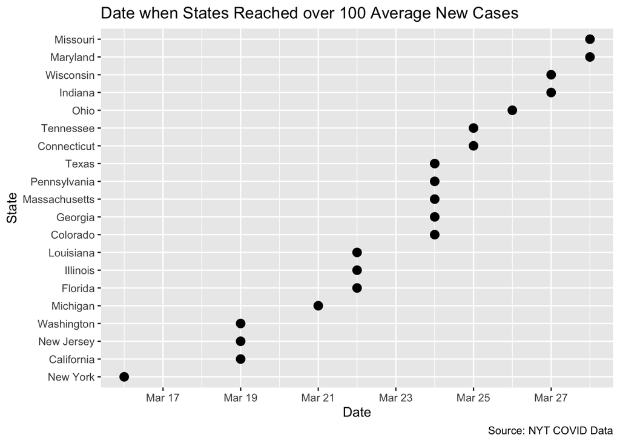

```r
# When each state reached > 100 average cases per day
library(ggrepel)

early_covid_data <- covid %>%
  filter(cases_avg > 100) %>%
  group_by(state) %>%
  slice_min(order_by = date, n = 1) %>%
  ungroup() %>%
  arrange(date) %>%
  mutate(state = reorder(state, date)) %>%
  slice_head(n = 20)

ggplot(data = early_covid_data, aes(x = date, y = state)) +
  geom_point(size = 3) +
  labs(
    title = "Date when States Reached over 100 Average New Cases",
    x = "Date",
    y = "State",
    caption = "Source: NYT COVID Data"
  )
```

The first five states to experience COVID early on were New York, California, New Jersey, Washington and Michigan. These states were the first states to have an average number of new cases greater than 100. New York reached this on March 16, 2020. California, New Jersey, and Washington reached this on March 19, 2020. Michigan reached this on March 21, 2020.